# Practical Machine Learning - Course Project

Katarzyna Senderowska

24.07.2015

### Introduction

Using devices such as Jawbone Up, Nike FuelBand, and Fitbit it is now possible to collect a large amount of data about personal activity relatively inexpensively. These type of devices are part of the quantified self movement – a group of enthusiasts who take measurements about themselves regularly to improve their health, to find patterns in their behavior, or because they are tech geeks. One thing that people regularly do is quantify how much of a particular activity they do, but they rarely quantify how well they do it. In this project data from accelerometers on the belt, forearm, arm, and dumbell of 6 participants was used. They were asked to perform barbell lifts correctly and incorrectly in 5 different ways. The aim of the project is to predict the manner in which they did the exercise.

### Exploratory data analysis & data cleaning

The data for this project comes from http://groupware.les.inf.puc-rio.br/har .

Datasets were downloaded from the website and read into R:

```r
download.file("https://d396qusza40orc.cloudfront.net/predmachlearn/pml-training.csv", destfile = "/home/kasia/pml-training.csv", method='curl')
download.file("https://d396qusza40orc.cloudfront.net/predmachlearn/pml-testing.csv", destfile = "/home/kasia/pml-testing.csv", method='curl')
data_training <- read.csv("/home/kasia/pml-training.csv")
data_test <- read.csv("/home/kasia/pml-testing.csv")
```

All necesarry packages were loaded:

```r
library(caret)
library(kernlab)
library(randomForest)
library(corrplot)
```

```r
isAnyMissing <- sapply(data_training, function (x) any(is.na(x) | x == ""))
data_training_removeNAs <- data_training[,which(isAnyMissing == FALSE)]
data_training_variables <- data_training_removeNAs[8:length(data_training_removeNAs)]

isAnyMissing2 <- sapply(data_test, function (x) any(is.na(x) | x == ""))
data_test_removeNAs <- data_test[,which(isAnyMissing2 == FALSE)]
data_test_variables <- data_test_removeNAs[8:length(data_test_removeNAs)]
```

### Machine Learning

The training dataset was split into two parts: training and cross validation, in 70:30 ratio.

```r
inTrain <- createDataPartition(y = data_training_variables$classe, p = 0.7, list = FALSE)
training <- data_training_variables[inTrain, ]
crossval <- data_training_variables[-inTrain, ]
```

A random forest model was chosen to predict the classification. Random forests operate by constructing a multitude of decision trees and outputting the class of the individual trees. Random forests correct for decision trees’ habit of overfitting to their training set, which boosts the performance of the final model.

A correllation plot was produced to check the correlations within each pair of variables.

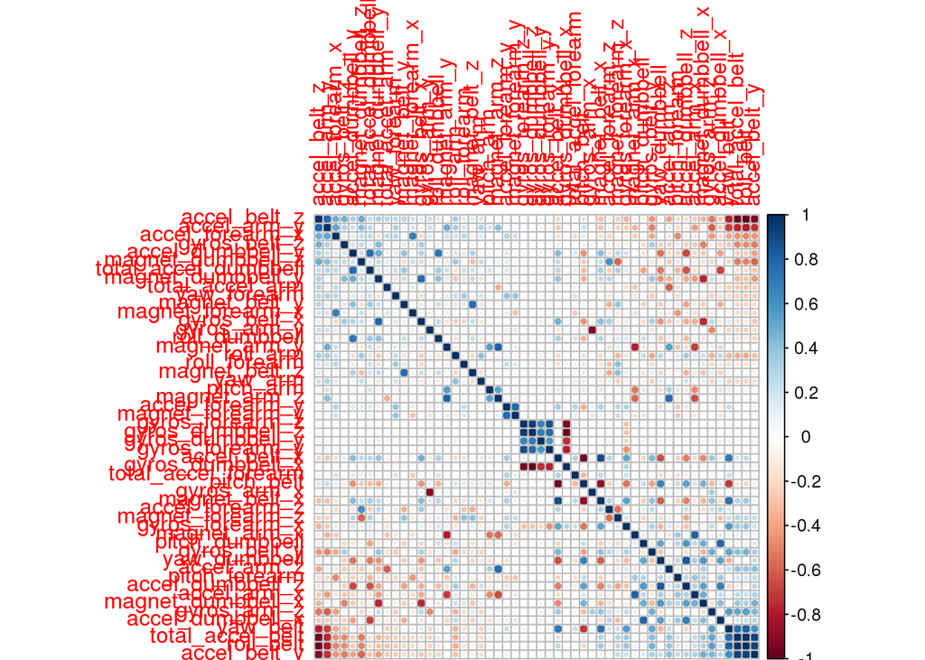

```r
correlation <- cor(training[, -length(training)])
corrplot(correlation, order = "FPC")
```

Highty correlated pairs of variables are marked in dark red (negative correlation coefficients) and dark blue (positive correlation coefficients). The plot shows that number of highly correlated pairs of variables is indeed very small. Therefore all predictors can be included in the model.

In the next step, random forest model was fitted to the data. Classe variable was set as an outcome. All remaninig variables were used as predictors.

```r
model <- randomForest(classe ~ ., data = training)
model
```

```
##
## Call:
##  randomForest(formula = classe ~ ., data = training)
##                Type of random forest: classification
##                      Number of trees: 500
## No. of variables tried at each split: 7
##
##         OOB estimate of  error rate: 0.52%
## Confusion matrix:
##      A    B    C    D    E class.error
## A 3901    3    1    0    1 0.001280082
## B   12 2641    5    0    0 0.006395786
## C    0   13 2381    2    0 0.006260434
## D    0    0   24 2226    2 0.011545293
## E    0    0    2    6 2517 0.003168317
```

The model resulted in very small OOB error rate of 0.5%. This is good enought to go to next steps of testing the model.

### Cross-validation and preditions on test data

Random Forest model described above was used to classify the remaining 30% of data. In order to detemine the accuracy of the model, the obtained results were presented in a confusion matrix and compared with the actual classifications.

```r
cross_validation <- predict(model, crossval)
confusionMatrix(crossval$classe, cross_validation)
```

```
## Confusion Matrix and Statistics
##
##           Reference
## Prediction    A    B    C    D    E
##          A 1673    1    0    0    0
##          B    5 1133    1    0    0
##          C    0    2 1024    0    0
##          D    0    0    7  957    0
##          E    0    0    1    7 1074
##
## Overall Statistics
##
##                Accuracy : 0.9959
##                  95% CI : (0.9939, 0.9974)
##     No Information Rate : 0.2851
##     P-Value [Acc > NIR] : < 2.2e-16
##
##                   Kappa : 0.9948
##  Mcnemar's Test P-Value : NA
##
## Statistics by Class:
##
##                      Class: A Class: B Class: C Class: D Class: E
## Sensitivity            0.9970   0.9974   0.9913   0.9927   1.0000
## Specificity            0.9998   0.9987   0.9996   0.9986   0.9983
## Pos Pred Value         0.9994   0.9947   0.9981   0.9927   0.9926
## Neg Pred Value         0.9988   0.9994   0.9981   0.9986   1.0000
## Prevalence             0.2851   0.1930   0.1755   0.1638   0.1825
## Detection Rate         0.2843   0.1925   0.1740   0.1626   0.1825
## Detection Prevalence   0.2845   0.1935   0.1743   0.1638   0.1839
## Balanced Accuracy      0.9984   0.9980   0.9954   0.9957   0.9992
```

The accuracy of the prediction is very high: 99.5%.

In the final step , the obtained model was used to predict the classifications for test data.

```r
test_data_predictions <- predict(model, data_test_variables)
test_data_predictions
```

```
##  1  2  3  4  5  6  7  8  9 10 11 12 13 14 15 16 17 18 19 20
##  B  A  B  A  A  E  D  B  A  A  B  C  B  A  E  E  A  B  B  B
## Levels: A B C D E
```

### Summary

The obtained results showed that Random Forest, relatively simple machine learning algorithm, performs very well for predicting activities from accelerometers measurements.